# R Notebook

# Evaluating Modelling Techniques to Detect Precursors to Landslides from InSAR-Based Data

**2026 Honours Project -**

```r
# Load packages

library(readxl)
library(ggplot2)
library(MASS)
library(factoextra)
library(gridExtra)
library(cluster)
library(clusterSim)
library(dbscan)
library(dtwclust)
library(patchwork)
library(ggplotify)
library(zoo)
library(tidyr)
library(dplyr)


set.seed(1234)
```

## 1. Prepare the data

Below is the original data. The next section defines the data that subsets only the TSF area points.

```r
cadia <- read_excel("../data/Cadia_PS_2018.xlsx")

peru_failed <- read_excel("../data/Cobriza_Peru_Failed_2019.xlsx")

peru_unfailed <- read_excel("../data/Cobriza_Peru_Unfailed_2019.xlsx")
```

```r
# Extracting displacement columns for Peru sites

# displacement columns
d_cols_peru_F <- grep("^D_", names(peru_failed), value = TRUE)
d_cols_peru_U <- grep("^D_", names(peru_unfailed), value = TRUE)

# keep baseline for sliding windows
peru_F <- as.matrix(
  peru_failed[, d_cols_peru_F]
)

peru_U <- as.matrix(
  peru_unfailed[, d_cols_peru_U]
)

dim(peru_F)
dim(peru_U)
```

There is too little data to apply coherence filtering to the Peru datasets.

```r
# metadata for exporting later
peru_F_info <- peru_failed %>%
  select(FID, lon, lat, coherence)

peru_U_info <- peru_unfailed %>%
  select(FID, lon, lat, coherence)
```

```r
# dates
peru_F_dates <- as.Date(
  sub("^D_", "", colnames(peru_F)),
  format = "%Y%m%d"
)

peru_U_dates <- as.Date(
  sub("^D_", "", colnames(peru_U)),
  format = "%Y%m%d"
)
```

```r
names(peru_failed)
head(peru_failed)
```

### 1.1 Subsetting the TSF areas

```r
# read smaller region csv - only for Cadia

cadia_tsf_only <- read.csv("../data/cadia_filtered_tsf_only.csv")

cadia_south_tsf_nonfailure <- read.csv("../data/cadia_nonfailure_tsf_only.csv")

head(cadia_tsf_only)
dim(cadia_tsf_only)

head(cadia_south_tsf_nonfailure)
dim(cadia_south_tsf_nonfailure)
```

```r
dim(cadia_tsf_only)
```

```r
library(ggplot2)

ggplot(cadia, aes(x = lon, y = lat)) +
  geom_point(size = 0.5) +
  coord_fixed() +
  labs(
    title = "Cadia InSAR points",
    x = "Longitude",
    y = "Latitude"
  )

ggplot(cadia_tsf_only, aes(x = lon, y = lat)) +
  geom_point(size = 0.5) +
  coord_fixed() +
  labs(
    title = "Cadia TSF InSAR points",
    x = "Longitude",
    y = "Latitude"
  )

ggplot(cadia_south_tsf_nonfailure, aes(x = lon, y = lat)) +
  geom_point(size = 0.5) +
  coord_fixed() +
  labs(
    title = "Cadia TSF InSAR points",
    x = "Longitude",
    y = "Latitude"
  )
```

### 1.2 Coherence Filtering

```r
# Only applicable for Cadia sites
  # Failed site

coherence_thresholds <- c(0.55, 0.60, 0.70)

for (t in coherence_thresholds) {

  n_keep <- sum(cadia_tsf_only$coherence >= t)
  pct_keep <- mean(cadia_tsf_only$coherence >= t) * 100

  cat(
    "Threshold:", t,
    "- Points:", n_keep,
    "- Percent:", round(pct_keep, 1), "%\n"
  )
}
```

```r
# Extract displacement cols - Cadia failed TSF

cadia_coherence_threshold <- 0.70

cadia_co_filtered <- cadia_tsf_only %>%
  filter(coherence >= cadia_coherence_threshold)

nrow(cadia_co_filtered)

d_cols_filtered <- grep(
  "^D_",
  names(cadia_co_filtered),
  value = TRUE
)

cadia_D_filtered <- cadia_co_filtered[, d_cols_filtered]

cadia_D_filtered <- as.matrix(cadia_D_filtered)
```

```r
dim(cadia_D_filtered)
```

```r
# filtered cadia dataset for sliding window
cadia_D_filtered_sliding <- cadia_D_filtered
```

```r
coherence_thresholds <- c(0.55, 0.60, 0.70)

for (t in coherence_thresholds) {

  n_keep <- sum(cadia_south_tsf_nonfailure$coherence >= t)
  pct_keep <- mean(cadia_south_tsf_nonfailure$coherence >= t) * 100

  cat(
    "Threshold:", t,
    "- Points:", n_keep,
    "- Percent:", round(pct_keep, 1), "%\n"
  )
}
```

```r
# Cadia Non failed
cadia_coherence_threshold <- 0.70

cadia_south_nonfailure_co_filtered <- cadia_south_tsf_nonfailure %>%
  filter(coherence >= cadia_coherence_threshold)

nrow(cadia_south_nonfailure_co_filtered)

# extract displacement cols

d_cols_filtered <- grep(
  "^D_",
  names(cadia_south_nonfailure_co_filtered),
  value = TRUE
)

cadia_south_D_filtered <- cadia_south_nonfailure_co_filtered[, d_cols_filtered]

cadia_south_D_filtered <- as.matrix(cadia_south_D_filtered)
```

```r
# filtered cadia dataset including 0 baseline
cadia_south_D_filtered_sliding <- cadia_south_D_filtered
```

Check that the first date (0) was retained:

```r
# Confirm baseline is retained
unique(cadia_D_filtered[, 1])
unique(cadia_south_D_filtered[, 1])
unique(peru_F[, 1])
unique(peru_U[, 1])

colnames(cadia_D_filtered)[1:3]
colnames(cadia_south_D_filtered)[1:3]
colnames(peru_F)[1:3]
colnames(peru_U)[1:3]
```

## 2. Explanations

### 2.1 Old Expanding Window K-means Explanation

First implementation with a fixed threshold:

This omits the setup of storage matrices.

```r
# temporal clustering setup

set.seed(1234)

k <- 2
start_window <- 10
threshold <- -10

n_pts_filtered <- nrow(cadia_D_filtered)
n_dates_filtered <- ncol(cadia_D_filtered)

n_iters_filtered <-
  n_dates_filtered - start_window + 1

iter_dates_filtered <-
  colnames(cadia_D_filtered)[
    start_window:n_dates_filtered
  ]
```

Setup: Define the size of the starting window, size of k, and fixed threshold.

- I defined the fixed threshold here as an initial test to see if the implementation worked at all.
  - In later attempts, I checked multiple thresholds, but here was not as thorough.
- Also defined the total number of observations, dates, and resulting iterations (dates minus starting window size).

```r
for (i in start_window:n_dates_filtered) {

  x <- cadia_D_filtered[
    , 1:i,
    drop = FALSE
  ]

  km <- kmeans(
    x,
    centers = k,
    nstart = 20
  )

  # displacement at newest date
  latest_disp <- x[, ncol(x)]

  # current iteration number
  iter <- i - start_window + 1

  # store raw cluster membership
  cluster_membership_mat_filtered_k2[
    , iter
  ] <- km$cluster

  # median newest displacement
    # for each raw cluster
  cluster_medians <- tapply(
    latest_disp,
    km$cluster,
    median
  )

  # ordered medians only for plotting
  ordered_medians <- sort(
    cluster_medians
  )

  cluster_medians_mat_filtered_k2[
    iter,
  ] <- ordered_medians

  # classify each cluster using THRESHOLD
  cluster_status <- ifelse(
    cluster_medians <= threshold,
    1,   # concerning
    0    # non-concerning
  )

  # each point inherits its cluster's status
  pt_status <- cluster_status[
    km$cluster
  ]


  cluster_status_mat_filtered_k2[
    , iter
  ] <- pt_status
}
```

- Centroid: The average time series of the points in that cluster
- Normally: Random centroid initialisation -> calculate which centroid each point is closest to -> Assign points to clusters -> Calculate new centroid of each cluster by averaging its assigned points -> Reassign every point to its closest new centroid -> Calculate centroids again -> Repeat -> Once nothing changes = Final cluster + final centroids

Process:

1. Select the initial clustering window from the beginning of data to the current date. The process iterates through each window by 1.
2. K-means is applied independently to each expanding window.
- Each InSAR point is 1 observation.
- 20 random initial centroid configurations (nstart = 20) were evaluated and the solution with the lowest within-cluster sum of squares was retained.
3. The temporal window was expanded by one acquisition and K-means was repeated using all acquisitions from the initial reference acquisition to the new endpoint.
4. At each acquisition, the resulting cluster memberships are stored in a matrix.
- The raw cluster labels are arbitrary and do not themselves indicate whether a cluster represents greater or lesser deformation.
5. For interpretation / comparison against the threshold, we characterise the deformation represented by each cluster:
- For each resulting K-means cluster, we take all points belonging to that cluster and obtain each point’s cumulative displacement at the final acquisition of the current window.
- Calculate the median of these final cumulative displacement values (for each cluster)
- The resulting median was used as a cluster-level summary rather than thresholding individual points.
6. A fixed displacement threshold was applied to these cluster medians:
- For k = 2, “Status 1” was if the cluster median is equal or more negative than the threshold.
  - “Status 0” is if the cluster’s median was below the threshold.
  - Every point in that cluster receives the cluster’s status for that iteration. - The threshold does NOT affect the K-means clustering itself or determine which points belong to a cluster.
  - It is applied only after K-means to interpret the resulting clusters.
7. The process is repeated through all acquisitions.

Example:

- K-means produces 2 clusters at one iteration with median final cumulative displacements of:
  - Cluster 1: -8mm
  - Cluster 2: -2mm
- Fixed threshold = -5mm
  - Cluster 1 assigned Status 1.
  - Cluster 2 assigned Status 0.
- All points within the first cluster receive status 1, even though the individual points do not necessarily each exceed -5mm.

Note:

- I chose to use median cumulative displacement as it is less influenced by extreme individual measurements than using the mean.
- I understand that this approach is very dependent on the threshold.
- In later approaches (sliding window), threshold sensitivity is assessed separately to determine the affect of it on the clusters.
- In this approach, K-means identifies groups with similar temporal behaviour and applies the threshold to provide a consistent interpretation of the clusters.
- If I chose to assign status based on each individual point’s displacement against the threshold, then K-means would be useless.

### 2.2 New Expanding Window K-means Threshold

Revised implementation:

## 3. New Expanding Window Implementation

### 3.1 Cadia Failed Site

```r
# Setup

set.seed(1234)

k <- 2
start_window <- 10
threshold <- -10 # for consistency

n_pts <- nrow(cadia_D_filtered)
n_dates <- ncol(cadia_D_filtered)

n_iters <- n_dates - start_window + 1

# Date corresponding to the end of each expanding window
iter_dates <- colnames(cadia_D_filtered)[
  start_window:n_dates
]
```

```r
# storage matrices

# raw K-means membership for every point and iteration
membership <- matrix(
  NA,
  nrow = n_pts,
  ncol = n_iters
)

# raw cluster medians
  # retain raw cluster order here
cluster_medians <- matrix(
  NA,
  nrow = n_iters,
  ncol = k
)

# status 0/1
status <- matrix(
  NA,
  nrow = n_pts,
  ncol = n_iters
)

silhouette_values <- rep(NA, n_iters)

# used to carry solution into next iteration
prev_centers <- NULL
prev_cluster <- NULL
```

```r
# revised temporal loop
for (i in start_window:n_dates) {

  # Current iteration
  iter <- i - start_window + 1

  # Expanding window:
  # D1:D10, then D1:D11, ...
  x <- cadia_D_filtered[
    , 1:i,
    drop = FALSE
  ]


  # !! First window

  if (iter == 1) {

    # No previous centroids exist yet
    # so use normal multiple random starts
    km <- kmeans(
      x,
      centers = k,
      nstart = 100
    )

  # Subsequent windows !!

  } else {

    # Displacement of every InSAR point at the newly added acquisition
    new_date <- x[, ncol(x)]

    # For each previous cluster, calculate mean disp at new date
    new_center_values <- sapply(
      1:k,
      function(cl) {
        mean(
          new_date[prev_cluster == cl],
          na.rm = TRUE
        )
      }
    )


    # Add the new value onto each previous centroid
    initial_centers <- cbind(
      prev_centers,
      new_center_values
    )

    # Run K-means using these as the starting centroids
      # NO nstart
    km <- kmeans(
      x,
      centers = initial_centers
    )
  }

  # Store raw cluster membership
  membership[, iter] <- km$cluster


  # cluster median at latest date
  latest_disp <- x[, ncol(x)]

  current_medians <- sapply(
    1:k,
    function(cl) {
      median(
        latest_disp[km$cluster == cl],
        na.rm = TRUE
      )
    }
  )

  cluster_medians[iter, ] <- current_medians

  # Fixed threshold comparison to assign STATUS
  cluster_status <- ifelse(
    current_medians <= threshold,
    1,
    0
  )

  # Every point inherits its
    # CURRENT cluster's status
  status[, iter] <- cluster_status[
    km$cluster
  ]

  sil <- cluster::silhouette(
    km$cluster,
    dist(x)
  )

  silhouette_values[iter] <- mean(
    sil[, "sil_width"]
  )

  # save solution for next iteration !!
  prev_centers <- km$centers
  prev_cluster <- km$cluster
}
```

**Check results:**

```r
# check if previous memberships aren't forced onto the next window

membership_changes <- sapply(
  2:n_iters,
  function(j) {
    sum(membership[, j] != membership[, j - 1])
  }
)

membership_changes
```

```r
# Previous membership = first D1:D10 result
prev_membership_test <- membership[, 1]

# Mean D11 displacement for those previous clusters
sapply(
  1:k,
  function(cl) {
    mean(
      cadia_D_filtered[
        prev_membership_test == cl,
        11
      ]
    )
  }
)
```

```r
# Check dimensions
dim(membership)
dim(cluster_medians)
dim(status)

# Cluster medians
head(cluster_medians)
tail(cluster_medians)

# Number of points in each cluster over first few iterations
apply(
  membership[, 1:min(5, ncol(membership)), drop = FALSE],
  2,
  table
)
```

Threshold note: - This version does not include much backing for our threshold value. - It was chosen fairly subjectively as the first run of the algorithm to test if it works, based on visual inspection using both the graph of displacement from forensic investigation and looking at the calculated medians.

```r
# Confirm first expanding window starts at
# the 10th acquisition
colnames(cadia_D_filtered)[1:10]

# Confirm first acquisition is zero
unique(cadia_D_filtered[, 1])
```

```r
# status 1 thru time
percent_flagged <- colMeans(
  status == 1,
  na.rm = TRUE
) * 100

plot(
  as.Date(
    sub("^D_", "", iter_dates),
    format = "%Y%m%d"
  ),
  percent_flagged,
  type = "l",
  ylim = c(0, 100),
  xlab = "Date",
  ylab = "Points with Status 1 (%)",
  main = "Cadia - Expanding Window K-means"
)
```

To compare with the new implementation of hierarchical clustering that led to interesting results, we calcualte consecutive-window ARI here:

```r
library(mclust)

ari_kmeans <- numeric(n_iters - 1)

for (j in 2:n_iters) {

  ari_kmeans[j - 1] <- adjustedRandIndex(
    membership[, j - 1],
    membership[, j]
  )
}

summary(ari_kmeans)
```

```r
ari_dates <- as.Date(
  sub("^D_", "", iter_dates[-1]),
  format = "%Y%m%d"
)

plot(
  ari_dates,
  ari_kmeans,
  type = "b",
  pch = 16,
  ylim = c(0, 1),
  xlab = "Date",
  ylab = "Adjusted Rand Index",
  main = "K-means Stability Between Consecutive Expanding Windows"
)

abline(h = 1, lty = 2)
```

```r
plot(
  ari_dates,
  ari_kmeans,
  type = "l",
  ylim = c(-0.1, 1),
  xlab = "Date",
  ylab = "Adjusted Rand Index",
  main = "Expanding-Window Cluster Stability"
)

lines(
  ari_dates,
  ari_ward,
  lty = 2
)

legend(
  "bottomright",
  c("K-means", "Hierarchical clustering"),
  lty = c(1, 2)
)
```

#### 3.1.1 Comparison to HC

- Original HC implementation:
  - HC was rerun independently for every expanding window.
  - Each new acquisition changes the distances between the time-series, therfore HC constructs a new dendrogram from scratch each time.
  - Cutting each new dendrogram at k = 2 can place large branches of points into different clusters.
  - Additionally and IMPORTNANTLY, cluster labels 1 and 2 have no inherent temporal meaning, so there was a challenge with the labels simply reversing.
- HC and median ordering:
  - This was implemented to be similar to the K-means approach to try and give clusters 1 and 2 consistent meanings and physical interpretation.
  - However, it did not prevent the actual dendrogram structure from changing, so the large membership fluctuations remained.
- HC + Jaccard label matching:
  - Jaccard similarity matched each new cluster to the most overlapping cluster from the previous window.
  - This successfully removed changes purely by Cluster 1 and Cluster 2 label swapping.
  - But, large changes still remained (e.g. 49% points changed at one acquisition).
  - Therefore, a larger instability was identified in the Ward HC partition, not just the inconsistent labels.
- Average Linkage:
  - Much more stable, with generally less than 5% of points changing.
  - However, it produced extremely imbalanced clusters (e.g. 2,494 points vs 1 point).
  - Therefore, not necessarily a better clustering solution.
- Ward Linkage and ARI:
  - ARI directly measures how similar two consecutive partitions are.
    - Measures how similar two clusterings of the same points are.
    - ARI = 1: Identical clustering
    - ARI near 0: Very little agreement
    - ARI < 0: Agreement worse than expected by chance.
  - Ward showed strongly varying ARI at each acquisition, confirming that its clustering structure genuinely changes as acquisitions are added.
  - This suggests that the expanding-window HC itself is sensitive to the addition of new time acquisitions.

Therefore, the main problem encountered using hierarchical clustering for a temporal-based approach was:

- Each time a new InSAR acquisition was added, HC had to be recalculated by scratch.
- Adding a new date changes the time-series vectors and therefore changes the pairwise Euclidean distances between points.
- Creates a new dendrogram at every expanding window. Small changes in distances can change where branches merge, whole groups of points can move between clusters.
- HC does not maintain cluster labels through time.
  - Using Jaccard matching did not solve this.
- To try and fix this, we would need some form of dynamic HC that carries info from the previous hierarchy (at the previous iteration) into the next iteration, instead of rebuilding it every time.
- Difficult because unlike K-means where it has centroids, there is no simple object that can be extended to pass on previous info.
- It is hard to use the old dendrogram as well because the information/distances change by adding each new date.
- If we force the old structure to remain, it would veer away from conventional hierarchical clustering. I do not really know how to implement that and how I would justify that.
- So instead, I just kept conventional HC and used ARI to measure how much the independently reconstructed partitions changed.

#### 3.1.2 Threshold Test

We add a form of validation using a grid of thresholds to show how the data would behave over time with each.

- This is still relatively subjective.
- From a grid of displacement thresholds, we recalculate “Status” through time, and for each we ask “At this threshold, what percentage of InSAR points would be classified Status 1 (over the threshold)?”
- We can then plot these values over time together.
- For the first implementation, -10mm was used as the threshold.

```r
# Threshold range

threshold_grid_cadia_F <- c(-5, -7.5, -10, -12.5, -15, -17.5, -19)

threshold_grid_cadia_F
```

```r
# Recalculate status for each threshold

# store in matrix
threshold_results_cadia_F <- matrix(
  NA,
  nrow = n_iters,
  ncol = length(threshold_grid_cadia_F)
)

# rename
colnames(threshold_results_cadia_F) <- paste0(
  threshold_grid_cadia_F, " mm"
)

for (t in seq_along(threshold_grid_cadia_F)) {

  threshold_test <- threshold_grid_cadia_F[t]

  for (iter in 1:n_iters) {

    # Status of each cluster under this threshold
    cluster_status_test <- ifelse(
      cluster_medians[iter, ] <= threshold_test,
      1,
      0
    )

    # Status inherited by individual points
    point_status_test <- cluster_status_test[
      membership[, iter]
    ]

    # % of points Status 1
    threshold_results_cadia_F[iter, t] <- mean(
      point_status_test == 1
    ) * 100
  }
}
```

```r
# convert from wide to long to plot

threshold_df_cadia_F <- data.frame(
  Date = as.Date(
    sub("^D_", "", iter_dates),
    format = "%Y%m%d"
  ),
  threshold_results_cadia_F,
  check.names = FALSE
)

threshold_long_cadia_F <- threshold_df_cadia_F %>%
  pivot_longer(
    cols = -Date,
    names_to = "Threshold",
    values_to = "Percent_Flagged"
  )

threshold_long_cadia_F$Threshold <- factor(
  threshold_long_cadia_F$Threshold,
  levels = colnames(threshold_results_cadia_F)
)
```

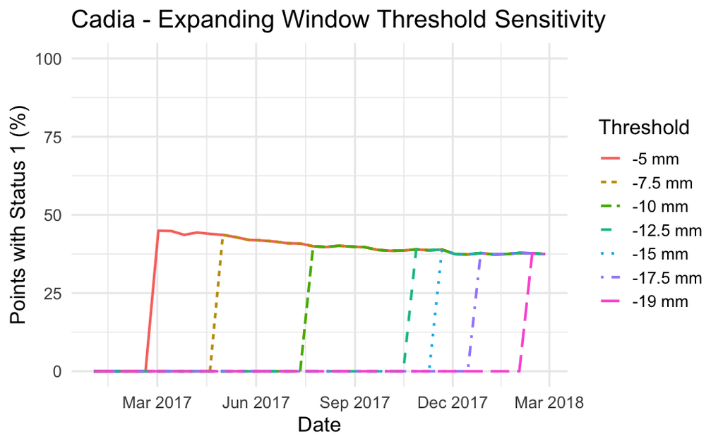

```r
p_cadia_threshold_F <- ggplot(
  threshold_long_cadia_F,
  aes(
    x = Date,
    y = Percent_Flagged,
    colour = Threshold,
    linetype = Threshold
  )
) +
  geom_line(linewidth = 0.9) +
  scale_x_date(
    date_breaks = "3 months",
    date_labels = "%b %Y"
  ) +
  scale_y_continuous(
    limits = c(0, 100),
    breaks = seq(0, 100, 25)
  ) +
  labs(
    title = "Cadia - Expanding Window Threshold Sensitivity",
    x = "Date",
    y = "Points with Status 1 (%)",
    colour = "Threshold",
    linetype = "Threshold"
  ) +
  theme_minimal(base_size = 15)

print(p_cadia_threshold_F)
```

```r
# Heatmap to better show the overlap

ggplot(
  threshold_long_cadia_F,
  aes(
    x = Date,
    y = Threshold,
    fill = Percent_Flagged
  )
) +
  geom_tile() +
  labs(
    title = "Cadia - Expanding Window Threshold Sensitivity",
    x = "Date",
    y = "Displacement threshold (mm)",
    fill = "Points classified\nas deformation (%)"
  ) +
  theme_minimal()
```

- These plots highlight the trade-off (ONLY in this instance) between earlier detection being more sensitive and later detection being less sensitive but only identifying deformation late.

Exporting:

```r
# Create point ID
cadia_info <- cadia_co_filtered %>%
  mutate(PointID = row_number()) %>%
  select(PointID, lon, lat)

# Convert results to LONG format
cadia_export <- do.call(
  rbind,
  lapply(1:n_iters, function(iter) {

    data.frame(
      PointID = cadia_info$PointID,
      lon = cadia_info$lon,
      lat = cadia_info$lat,
      Date = as.Date(
        sub("^D_", "", iter_dates[iter]),
        format = "%Y%m%d"
      ),
      Cluster = membership[, iter],
      Status = status[, iter]
    )
  })
)

# Check
head(cadia_export)
dim(cadia_export)

# Export
write.csv(
  cadia_export,
  "../outputs/cadia_new_expanding_km2_threshold10.csv",
  row.names = FALSE
)
```

### 3.2 Cadia Unfailed Site (South TSF)

```r
# Setup

set.seed(1234)

k <- 2
start_window <- 10
threshold_south <- -10

n_pts_south <- nrow(cadia_south_D_filtered)
n_dates_south <- ncol(cadia_south_D_filtered)

n_iters_south <- n_dates_south - start_window + 1

iter_dates_south <- colnames(cadia_south_D_filtered)[
  start_window:n_dates_south
]

# Check zero reference acquisition retained
unique(cadia_south_D_filtered[, 1])
```

```r
# storage matrices

membership_south <- matrix(
  NA,
  nrow = n_pts_south,
  ncol = n_iters_south
)

cluster_medians_south <- matrix(
  NA,
  nrow = n_iters_south,
  ncol = k
)

status_south <- matrix(
  NA,
  nrow = n_pts_south,
  ncol = n_iters_south
)

silhouette_values_south <- rep(
  NA,
  n_iters_south
)

prev_centers_south <- NULL
prev_cluster_south <- NULL
```

```r
# New temporal loop

for (i in start_window:n_dates_south) {

  iter <- i - start_window + 1

  # D1:D10, then D1:D11, D1:D12, ...
  x <- cadia_south_D_filtered[
    , 1:i,
    drop = FALSE
  ]

  # First window
  if (iter == 1) {

    km <- kmeans(
      x,
      centers = k,
      nstart = 100
    )

  } else {

    # Newly added acquisition
    new_date <- x[, ncol(x)]

    # Mean new-date displacement of points
    # belonging to each previous cluster
    new_center_values <- sapply(
      1:k,
      function(cl) {
        mean(
          new_date[prev_cluster_south == cl],
          na.rm = TRUE
        )
      }
    )

    # Extend previous centroids by one acquisition
    initial_centers <- cbind(
      prev_centers_south,
      new_center_values
    )

    # K-means starts from previous solution
    km <- kmeans(
      x,
      centers = initial_centers
    )
  }

  # Store membership
  membership_south[, iter] <- km$cluster

  # Median displacement at latest acquisition
  latest_disp <- x[, ncol(x)]

  current_medians <- sapply(
    1:k,
    function(cl) {
      median(
        latest_disp[km$cluster == cl],
        na.rm = TRUE
      )
    }
  )

  cluster_medians_south[iter, ] <- current_medians

  # Status using SAME -10 mm threshold
  cluster_status <- ifelse(
    current_medians <= threshold_south,
    1,
    0
  )

  status_south[, iter] <- cluster_status[
    km$cluster
  ]

  sil <- cluster::silhouette(
    km$cluster,
    dist(x)
  )

  silhouette_values_south[iter] <- mean(
    sil[, "sil_width"]
  )

  # Carry fitted solution forward
  prev_centers_south <- km$centers
  prev_cluster_south <- km$cluster
}
```

```r
dim(membership_south)
dim(cluster_medians_south)

head(cluster_medians_south)
tail(cluster_medians_south)

summary(silhouette_values_south)

range(cluster_medians_south, na.rm = TRUE)
```

```r
# ARI

library(mclust)

ari_south <- numeric(n_iters_south - 1)

for (j in 2:n_iters_south) {

  ari_south[j - 1] <- adjustedRandIndex(
    membership_south[, j - 1],
    membership_south[, j]
  )
}

summary(ari_south)
```

#### 3.2.1 Threshold Sensitivity Test

```r
# Same threshold grid as Cadia failed site

threshold_grid_cadia_F
```

```r
# Test
threshold_results_cadia_south <- matrix(
  NA,
  nrow = n_iters_south,
  ncol = length(threshold_grid_cadia_F)
)

colnames(threshold_results_cadia_south) <- paste0(
  threshold_grid_cadia_F,
  " mm"
)

for (t in seq_along(threshold_grid_cadia_F)) {

  threshold_test <- threshold_grid_cadia_F[t]

  for (iter in 1:n_iters_south) {

    cluster_status_test <- ifelse(
      cluster_medians_south[iter, ] <= threshold_test,
      1,
      0
    )

    point_status_test <- cluster_status_test[
      membership_south[, iter]
    ]

    threshold_results_cadia_south[iter, t] <- mean(
      point_status_test == 1
    ) * 100
  }
}
```

```r
# convert for plot
threshold_df_cadia_south <- data.frame(
  Date = as.Date(
    sub("^D_", "", iter_dates_south),
    format = "%Y%m%d"
  ),
  threshold_results_cadia_south,
  check.names = FALSE
)

threshold_long_cadia_south <- threshold_df_cadia_south %>%
  pivot_longer(
    cols = -Date,
    names_to = "Threshold",
    values_to = "Percent_Flagged"
  )

threshold_long_cadia_south$Threshold <- factor(
  threshold_long_cadia_south$Threshold,
  levels = colnames(threshold_results_cadia_south)
)
```

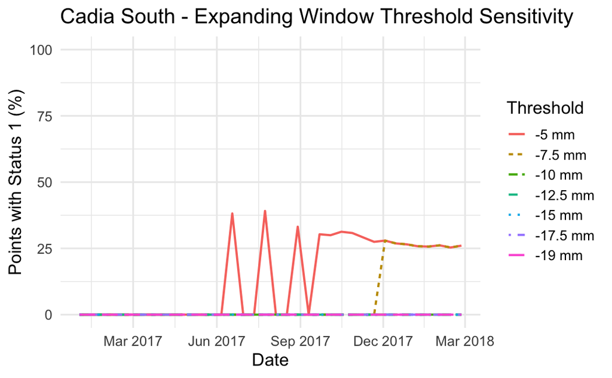

```r
# Plot
p_cadia_threshold_U <- ggplot(
  threshold_long_cadia_south,
  aes(
    x = Date,
    y = Percent_Flagged,
    colour = Threshold,
    linetype = Threshold
  )
) +
  geom_line(linewidth = 0.9) +
  scale_x_date(
    date_breaks = "3 months",
    date_labels = "%b %Y"
  ) +
  scale_y_continuous(
    limits = c(0, 100),
    breaks = seq(0, 100, 25)
  ) +
  labs(
    title = "Cadia South - Expanding Window Threshold Sensitivity",
    x = "Date",
    y = "Points with Status 1 (%)",
    colour = "Threshold",
    linetype = "Threshold"
  ) +
  theme_minimal(base_size = 15)

print(p_cadia_threshold_U)
```

```r
# Heatmap
ggplot(
  threshold_long_cadia_south,
  aes(
    x = Date,
    y = Threshold,
    fill = Percent_Flagged
  )
) +
  geom_tile() +
  labs(
    title = "Cadia South - Expanding Window Threshold Sensitivity",
    x = "Date",
    y = "Displacement threshold (mm)",
    fill = "Points classified\nas deformation (%)"
  ) +
  theme_minimal()
```

Comparing the threshold sensitivity test with both Cadia sites: - Initial -10mm threshold was selected empirically during preliminary testing, using previous literature/visual examples (Rana et al.) and inspection of the Cadia forensic displacement behaviour + our calculated cluster medians. - The sensitivity analysis was used the evaluate how this subjective choice compares to others. - For the failed site, progressively more negative thresholds classify the deformation-related cluster progressively later. - For the nonfailed site, the cluster median reached approx. -8.9mm and stopped. - Therefore, -10mm shows the difference in site deformation behaviour. - However, it should not be interpreted as a global physical failure threshold. - Appropriate thresholds are ALWAYS site-dependent and should incorporate site-specific deformation behaviour, engineering knowledge, and other monitoring information.

Exporting:

```r
cadia_south_info <- cadia_south_nonfailure_co_filtered %>%
  mutate(PointID = row_number()) %>%
  select(PointID, lon, lat)

cadia_south_export <- do.call(
  rbind,
  lapply(1:n_iters_south, function(iter) {

    data.frame(
      PointID = cadia_south_info$PointID,
      lon = cadia_south_info$lon,
      lat = cadia_south_info$lat,
      Date = as.Date(
        sub("^D_", "", iter_dates_south[iter]),
        format = "%Y%m%d"
      ),
      Cluster = membership_south[, iter],
      Status = status_south[, iter]
    )
  })
)

head(cadia_south_export)
dim(cadia_south_export)

write.csv(
  cadia_south_export,
  "../outputs/cadia_south_expanding_km2_threshold10.csv",
  row.names = FALSE
)
```

```r
ggsave(
  "../outputs/cadia_failed_threshold_sensitivity.png",
  plot = p_cadia_threshold_F,
  width = 11,
  height = 7,
  dpi = 300
)

ggsave(
  "../outputs/cadia_south_threshold_sensitivity.png",
  plot = p_cadia_threshold_U,
  width = 11,
  height = 7,
  dpi = 300
)
```

### 3.3 Peru Failed Site

```r
# Setup

### 3.3 Peru Failed Site

set.seed(1234)

k <- 2
start_window <- 10

# Initial threshold
threshold_peru <- -5

n_pts_peru_F <- nrow(peru_F)
n_dates_peru_F <- ncol(peru_F)

n_iters_peru_F <-
  n_dates_peru_F - start_window + 1

iter_dates_peru_F <- colnames(peru_F)[
  start_window:n_dates_peru_F
]

# Check baseline
unique(peru_F[, 1])
```

```r
dim(peru_F)
```

```r
# Storage matrices
membership_peru_F <- matrix(
  NA,
  nrow = n_pts_peru_F,
  ncol = n_iters_peru_F
)

cluster_medians_peru_F <- matrix(
  NA,
  nrow = n_iters_peru_F,
  ncol = k
)

status_peru_F <- matrix(
  NA,
  nrow = n_pts_peru_F,
  ncol = n_iters_peru_F
)

silhouette_peru_F <- rep(
  NA,
  n_iters_peru_F
)

prev_centers_peru_F <- NULL
prev_cluster_peru_F <- NULL
```

```r
# Temporal loop

for (i in start_window:n_dates_peru_F) {

  iter <- i - start_window + 1

  # Expanding window
  # D1:D10, D1:D11, ...
  x <- peru_F[
    , 1:i,
    drop = FALSE
  ]

  # First window
  if (iter == 1) {

    km <- kmeans(
      x,
      centers = k,
      nstart = 100
    )

  } else {

    # Newly added acquisition
    new_date <- x[, ncol(x)]

    # Mean displacement at new acquisition
    # for each PREVIOUS cluster
    new_center_values <- sapply(
      1:k,
      function(cl) {
        mean(
          new_date[prev_cluster_peru_F == cl],
          na.rm = TRUE
        )
      }
    )

    # Extend previous centroids
    initial_centers <- cbind(
      prev_centers_peru_F,
      new_center_values
    )

    # Initialise K-means using previous solution
    km <- kmeans(
      x,
      centers = initial_centers
    )
  }

  # Store CURRENT memberships
  membership_peru_F[, iter] <- km$cluster

  # Displacement at current final acquisition
  latest_disp <- x[, ncol(x)]

  # Median latest displacement of each cluster
  current_medians <- sapply(
    1:k,
    function(cl) {
      median(
        latest_disp[km$cluster == cl],
        na.rm = TRUE
      )
    }
  )

  cluster_medians_peru_F[iter, ] <-
    current_medians

  # Temporary status
  cluster_status <- ifelse(
    current_medians <= threshold_peru,
    1,
    0
  )

  status_peru_F[, iter] <-
    cluster_status[km$cluster]

  sil <- cluster::silhouette(
    km$cluster,
    dist(x)
  )

  silhouette_peru_F[iter] <-
    mean(sil[, "sil_width"])

  # Carry solution forward
  prev_centers_peru_F <- km$centers
  prev_cluster_peru_F <- km$cluster
}
```

Check results:

```r
dim(membership_peru_F)
dim(cluster_medians_peru_F)

head(cluster_medians_peru_F)
tail(cluster_medians_peru_F)

range(
  cluster_medians_peru_F,
  na.rm = TRUE
)

# summary(silhouette_peru_F)

apply(
  membership_peru_F[
    , 1:min(5, ncol(membership_peru_F)),
    drop = FALSE
  ],
  2,
  table
)
```

### 3.4 Peru Unfailed Site

```r
dim(peru_U)
```

```r
# Setup

set.seed(1234)

k <- 2
start_window <- 10

# Initial threshold
threshold_peru <- -5

n_pts_peru_U <- nrow(peru_U)
n_dates_peru_U <- ncol(peru_U)

n_iters_peru_U <-
  n_dates_peru_U - start_window + 1

iter_dates_peru_U <- colnames(peru_U)[
  start_window:n_dates_peru_U
]

# Check baseline
unique(peru_U[, 1])
```

```r
# Storage matrices
membership_peru_U <- matrix(
  NA,
  nrow = n_pts_peru_U,
  ncol = n_iters_peru_U
)

cluster_medians_peru_U <- matrix(
  NA,
  nrow = n_iters_peru_U,
  ncol = k
)

status_peru_U <- matrix(
  NA,
  nrow = n_pts_peru_U,
  ncol = n_iters_peru_U
)

silhouette_peru_U <- rep(
  NA,
  n_iters_peru_U
)

prev_centers_peru_U <- NULL
prev_cluster_peru_U <- NULL
```

```r
# Temporal loop

for (i in start_window:n_dates_peru_U) {

  iter <- i - start_window + 1

  # Expanding window
  # D1:D10, D1:D11, ...
  x <- peru_U[
    , 1:i,
    drop = FALSE
  ]

  # First window
  if (iter == 1) {

    km <- kmeans(
      x,
      centers = k,
      nstart = 100
    )

  } else {

    # Newly added acquisition
    new_date <- x[, ncol(x)]

    # Mean displacement at new acquisition
    # for each PREVIOUS cluster
    new_center_values <- sapply(
      1:k,
      function(cl) {
        mean(
          new_date[prev_cluster_peru_U == cl],
          na.rm = TRUE
        )
      }
    )

    # Extend previous centroids
    initial_centers <- cbind(
      prev_centers_peru_U,
      new_center_values
    )

    # Initialise K-means using previous solution
    km <- kmeans(
      x,
      centers = initial_centers
    )
  }

  # Store CURRENT memberships
  membership_peru_U[, iter] <- km$cluster

  # Displacement at current final acquisition
  latest_disp <- x[, ncol(x)]

  # Median latest displacement of each cluster
  current_medians <- sapply(
    1:k,
    function(cl) {
      median(
        latest_disp[km$cluster == cl],
        na.rm = TRUE
      )
    }
  )

  cluster_medians_peru_U[iter, ] <-
    current_medians

  # Temporary status
  cluster_status <- ifelse(
    current_medians <= threshold_peru,
    1,
    0
  )

  status_peru_U[, iter] <-
    cluster_status[km$cluster]

  sil <- cluster::silhouette(
    km$cluster,
    dist(x)
  )

  silhouette_peru_U[iter] <-
    mean(sil[, "sil_width"])

  # Carry solution forward
  prev_centers_peru_U <- km$centers
  prev_cluster_peru_U <- km$cluster
}
```

Check results:

```r
# median ranges FOR BOTH SITES

range(
  cluster_medians_peru_F,
  na.rm = TRUE
)

range(
  cluster_medians_peru_U,
  na.rm = TRUE
)
```

```r
tail(cluster_medians_peru_F)
tail(cluster_medians_peru_U)
```

#### 3.4.1 Threshold Sensitivity Test

Same threshold for both sites.

```r
threshold_grid_peru <- c(
  -2, -3, -4, -5, -6, -7, -8
)
```

```r
# Failed site

threshold_results_peru_F <- matrix(
  NA,
  nrow = n_iters_peru_F,
  ncol = length(threshold_grid_peru)
)

colnames(threshold_results_peru_F) <- paste0(
  threshold_grid_peru,
  " mm"
)

for (t in seq_along(threshold_grid_peru)) {

  threshold_test <- threshold_grid_peru[t]

  for (iter in 1:n_iters_peru_F) {

    cluster_status_test <- ifelse(
      cluster_medians_peru_F[iter, ] <= threshold_test,
      1,
      0
    )

    point_status_test <- cluster_status_test[
      membership_peru_F[, iter]
    ]

    threshold_results_peru_F[iter, t] <- mean(
      point_status_test == 1
    ) * 100
  }
}
```

```r
threshold_df_peru_F <- data.frame(
  Date = as.Date(
    sub("^D_", "", iter_dates_peru_F),
    format = "%Y%m%d"
  ),
  threshold_results_peru_F,
  check.names = FALSE
)

threshold_long_peru_F <- threshold_df_peru_F %>%
  pivot_longer(
    cols = -Date,
    names_to = "Threshold",
    values_to = "Percent_Flagged"
  )

threshold_long_peru_F$Threshold <- factor(
  threshold_long_peru_F$Threshold,
  levels = colnames(threshold_results_peru_F)
)
```

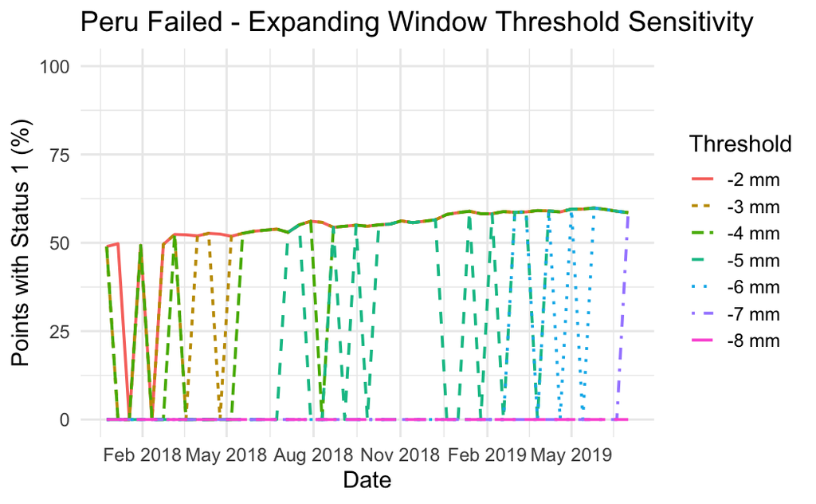

```r
# plots

p_peru_threshold_F <- ggplot(
  threshold_long_peru_F,
  aes(
    x = Date,
    y = Percent_Flagged,
    colour = Threshold,
    linetype = Threshold
  )
) +
  geom_line(linewidth = 0.9) +
  scale_x_date(
    date_breaks = "3 months",
    date_labels = "%b %Y"
  ) +
  labs(
    title = "Peru Failed - Expanding Window Threshold Sensitivity",
    x = "Date",
    y = "Points with Status 1 (%)",
    colour = "Threshold",
    linetype = "Threshold"
  ) +
  scale_y_continuous(
    limits = c(0, 100),
    breaks = seq(0, 100, 25)
  ) +
  theme_minimal(base_size = 15)

print(p_peru_threshold_F)
```

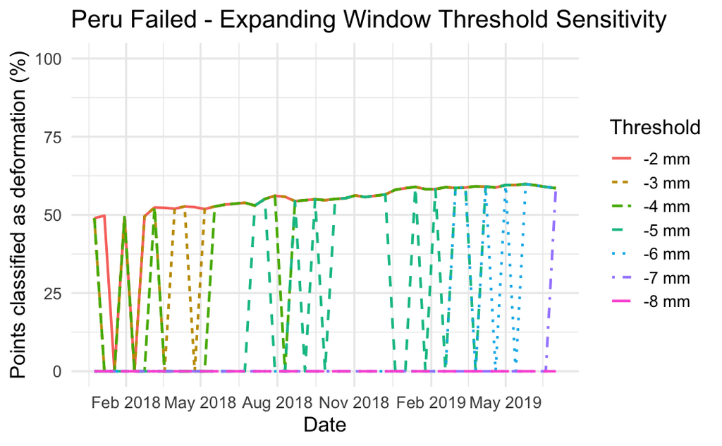

```r
p_peru_threshold_F <- ggplot(
  threshold_long_peru_F,
  aes(
    x = Date,
    y = Percent_Flagged,
    colour = Threshold,
    linetype = Threshold
  )
) +
  geom_line(linewidth = 0.9) +
  scale_x_date(
    date_breaks = "3 months",
    date_labels = "%b %Y"
  ) +
  labs(
    title = "Peru Failed - Expanding Window Threshold Sensitivity",
    x = "Date",
    y = "Points classified as deformation (%)",
    colour = "Threshold",
    linetype = "Threshold"
  ) +
  scale_y_continuous(
    limits = c(0, 100),
    breaks = seq(0, 100, 25)
  ) +
  theme_minimal(base_size = 15)

print(p_peru_threshold_F)
```

```r
# Unfailed site

threshold_results_peru_U <- matrix(
  NA,
  nrow = n_iters_peru_U,
  ncol = length(threshold_grid_peru)
)

colnames(threshold_results_peru_U) <- paste0(
  threshold_grid_peru,
  " mm"
)

# Test each threshold
for (t in seq_along(threshold_grid_peru)) {

  threshold_test <- threshold_grid_peru[t]

  for (iter in 1:n_iters_peru_U) {

    # Classify each cluster using current threshold
    cluster_status_test <- ifelse(
      cluster_medians_peru_U[iter, ] <= threshold_test,
      1,
      0
    )

    # Each point inherits its cluster's status
    point_status_test <- cluster_status_test[
      membership_peru_U[, iter]
    ]

    # Percentage of points classified as deformation
    threshold_results_peru_U[iter, t] <- mean(
      point_status_test == 1
    ) * 100
  }
}
```

```r
# Convert to long format

threshold_df_peru_U <- data.frame(
  Date = as.Date(
    sub("^D_", "", iter_dates_peru_U),
    format = "%Y%m%d"
  ),
  threshold_results_peru_U,
  check.names = FALSE
)

threshold_long_peru_U <- threshold_df_peru_U %>%
  pivot_longer(
    cols = -Date,
    names_to = "Threshold",
    values_to = "Percent_Flagged"
  )

threshold_long_peru_U$Threshold <- factor(
  threshold_long_peru_U$Threshold,
  levels = colnames(threshold_results_peru_U)
)
```

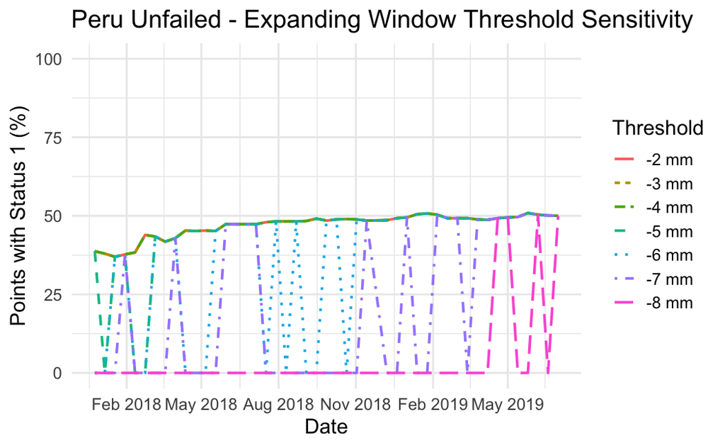

```r
p_peru_threshold_U <- ggplot(
  threshold_long_peru_U,
  aes(
    x = Date,
    y = Percent_Flagged,
    colour = Threshold,
    linetype = Threshold
  )
) +
  geom_line(linewidth = 0.9) +
  scale_x_date(
    date_breaks = "3 months",
    date_labels = "%b %Y"
  ) +
  labs(
    title = "Peru Unfailed - Expanding Window Threshold Sensitivity",
    x = "Date",
    y = "Points with Status 1 (%)",
    colour = "Threshold",
    linetype = "Threshold"
  ) +
  scale_y_continuous(
    limits = c(0, 100),
    breaks = seq(0, 100, 25)
  ) +
  theme_minimal(base_size = 15)

print(p_peru_threshold_U)
```

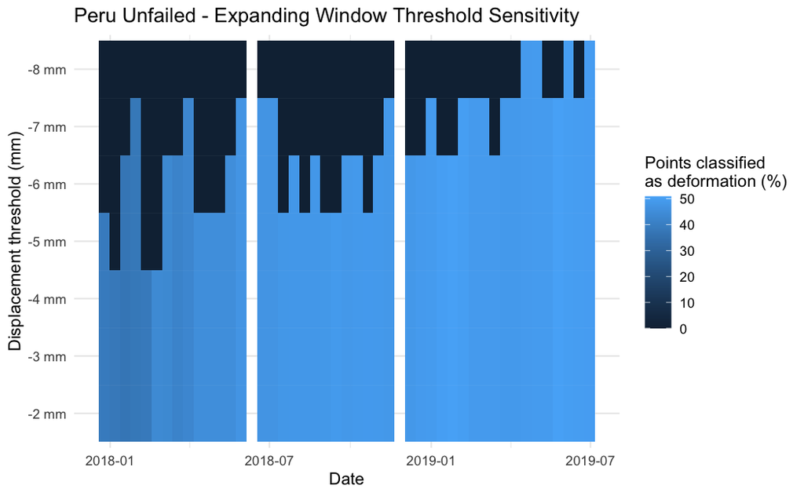

```r
ggplot(
  threshold_long_peru_U,
  aes(
    x = Date,
    y = Threshold,
    fill = Percent_Flagged
  )
) +
  geom_tile() +
  labs(
    title = "Peru Unfailed - Expanding Window Threshold Sensitivity",
    x = "Date",
    y = "Displacement threshold (mm)",
    fill = "Points classified\nas deformation (%)"
  ) +
  theme_minimal()
```

```r
ggsave(
  "../outputs/peru_failed_threshold_sensitivity.png",
  plot = p_peru_threshold_F,
  width = 11,
  height = 7,
  dpi = 300
)

ggsave(
  "../outputs/peru_unfailed_threshold_sensitivity.png",
  plot = p_peru_threshold_U,
  width = 11,
  height = 7,
  dpi = 300
)
```

```r
# Compare failed vs unfailed directly at -5 mm

comparison_peru <- bind_rows(

  data.frame(
    Date = as.Date(
      sub("^D_", "", iter_dates_peru_F),
      format = "%Y%m%d"
    ),
    Percent_Flagged =
      threshold_results_peru_F[, "-5 mm"],
    Site = "Failed"
  ),

  data.frame(
    Date = as.Date(
      sub("^D_", "", iter_dates_peru_U),
      format = "%Y%m%d"
    ),
    Percent_Flagged =
      threshold_results_peru_U[, "-5 mm"],
    Site = "Unfailed"
  )
)

ggplot(
  comparison_peru,
  aes(
    x = Date,
    y = Percent_Flagged,
    colour = Site
  )
) +
  geom_line(linewidth = 1) +
  labs(
    title = "Peru Failed vs Unfailed - Threshold = -5 mm",
    x = "Date",
    y = "Points classified as deformation (%)",
    colour = "Site"
  ) +
  ylim(0, 100) +
  theme_minimal()
```

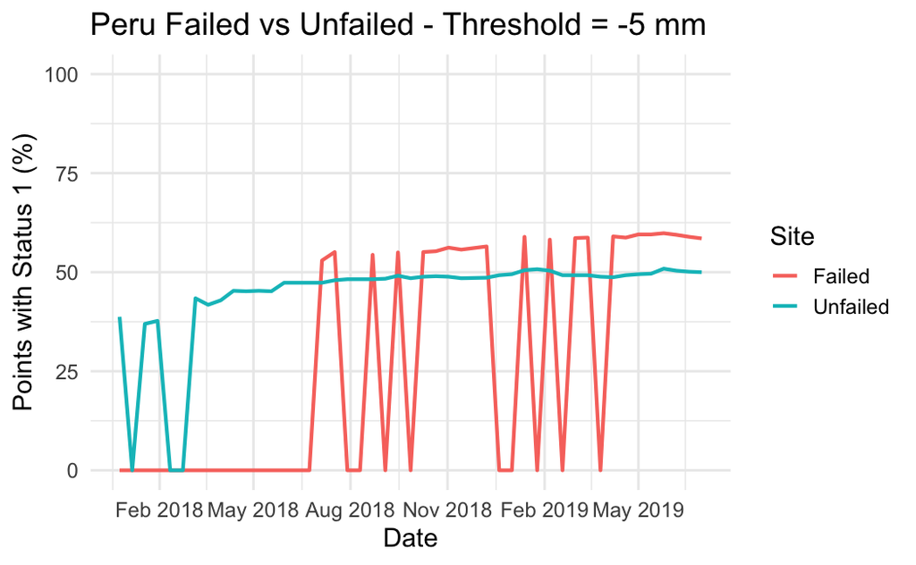

```r
p_peru <- ggplot(
  comparison_peru,
  aes(
    x = Date,
    y = Percent_Flagged,
    colour = Site
  )
) +
  geom_line(linewidth = 1) +
  scale_x_date(
    date_breaks = "3 months",
    date_labels = "%b %Y"
  ) +
  scale_colour_manual(
    values = c(
      "Failed" = "#F8766D",
      "Unfailed" = "#00BFC4"
    )
  ) +
  scale_y_continuous(
    limits = c(0, 100),
    breaks = seq(0, 100, 25)
  ) +
  labs(
    title = "Peru Failed vs Unfailed - Threshold = -5 mm",
    x = "Date",
    y = "Points with Status 1 (%)",
    colour = "Site"
  ) +
  theme_minimal(base_size = 15)

print(p_peru)

# Export
ggsave(
  "../outputs/peru_failed_vs_unfailed_threshold5.png",
  plot = p_peru,
  width = 11,
  height = 7,
  dpi = 300
)
```

```r
negative_median_F <- apply(
  cluster_medians_peru_F,
  1,
  min,
  na.rm = TRUE
)

negative_median_U <- apply(
  cluster_medians_peru_U,
  1,
  min,
  na.rm = TRUE
)

median_comparison_peru <- bind_rows(
  data.frame(
    Date = as.Date(
      sub("^D_", "", iter_dates_peru_F),
      format = "%Y%m%d"
    ),
    Median = negative_median_F,
    Site = "Failed"
  ),
  data.frame(
    Date = as.Date(
      sub("^D_", "", iter_dates_peru_U),
      format = "%Y%m%d"
    ),
    Median = negative_median_U,
    Site = "Unfailed"
  )
)

ggplot(
  median_comparison_peru,
  aes(
    x = Date,
    y = Median,
    colour = Site
  )
) +
  geom_line(linewidth = 1) +
  geom_hline(
    yintercept = -5,
    linetype = 2
  ) +
  labs(
    title = "Peru - More Negative Cluster Median Through Time",
    x = "Date",
    y = "Median cumulative displacement (mm)",
    colour = "Site"
  ) +
  theme_minimal()
```

Threshold sensitivity test notes: - Very different to Cadia, cumulative displacement magnitude did not provide clear separation between the failed and unfailed Peru cases. - Exploratory -4mm threshold: The failed site’s deformation-related cluster initially fluctated above and below the threshold until remaining below it from approx. mid-2018. - Unfailed site’s more negative cluster was generally below -4mm throughout the period AND reached a greater negative cumulative displacement than the failed site. - Therefore, increasing the threshold does not necessarily improve the comparison between site behaviour. - For exporting, we select a slightly lower threshold of -5mm. - This was informed by the above analysis, and we note that no individual threshold clearly separated the failed and unfailed cases.

```r
# New threshold status
threshold_peru <- -5

# Failed
status_peru_F_final <- matrix(
  NA,
  nrow = nrow(membership_peru_F),
  ncol = ncol(membership_peru_F)
)

for (iter in 1:n_iters_peru_F) {

  cluster_status <- ifelse(
    cluster_medians_peru_F[iter, ] <= threshold_peru,
    1,
    0
  )

  status_peru_F_final[, iter] <-
    cluster_status[membership_peru_F[, iter]]
}


# Unfailed
status_peru_U_final <- matrix(
  NA,
  nrow = nrow(membership_peru_U),
  ncol = ncol(membership_peru_U)
)

for (iter in 1:n_iters_peru_U) {

  cluster_status <- ifelse(
    cluster_medians_peru_U[iter, ] <= threshold_peru,
    1,
    0
  )

  status_peru_U_final[, iter] <-
    cluster_status[membership_peru_U[, iter]]
}
```

```r
percent_F_final <- colMeans(
  status_peru_F_final == 1,
  na.rm = TRUE
) * 100

percent_U_final <- colMeans(
  status_peru_U_final == 1,
  na.rm = TRUE
) * 100
```

```r
percent_U_final
```

Exporting both sites:

```r
# FAILED
peru_F_export <- do.call(
  rbind,
  lapply(1:n_iters_peru_F, function(iter) {

    data.frame(
      PointID = peru_F_info$FID,
      lon = peru_F_info$lon,
      lat = peru_F_info$lat,
      Date = as.Date(
        sub("^D_", "", iter_dates_peru_F[iter]),
        format = "%Y%m%d"
      ),
      Cluster = membership_peru_F[, iter],
      Status = status_peru_F_final[, iter]
    )
  })
)

write.csv(
  peru_F_export,
  "../outputs/peru_failed_expanding_km2_threshold5.csv",
  row.names = FALSE
)


# UNFAILED
peru_U_export <- do.call(
  rbind,
  lapply(1:n_iters_peru_U, function(iter) {

    data.frame(
      PointID = peru_U_info$FID,
      lon = peru_U_info$lon,
      lat = peru_U_info$lat,
      Date = as.Date(
        sub("^D_", "", iter_dates_peru_U[iter]),
        format = "%Y%m%d"
      ),
      Cluster = membership_peru_U[, iter],
      Status = status_peru_U_final[, iter]
    )
  })
)

write.csv(
  peru_U_export,
  "../outputs/peru_unfailed_expanding_km2_threshold5.csv",
  row.names = FALSE
)
```

```r
head(cadia_export, 15)
tail(cadia_export, 15)

length(unique(cadia_export$PointID))
length(unique(cadia_export$Date))

nrow(cadia_export) ==
  length(unique(cadia_export$PointID)) *
  length(unique(cadia_export$Date))
```

Exporting regular Peru CSVs for cumulative displacement animations:

```r
peru_failed_disp_long <- peru_failed %>%
  select(FID, lon, lat, all_of(d_cols_peru_F)) %>%

  pivot_longer(
    cols = all_of(d_cols_peru_F),
    names_to = "Date",
    values_to = "Displacement"
  ) %>%

  mutate(
    Date = as.Date(
      sub("^D_", "", Date),
      format = "%Y%m%d"
    )
  ) %>%

  rename(
    PointID = FID
  )

# Check
head(peru_failed_disp_long)
dim(peru_failed_disp_long)

# Export
write.csv(
  peru_failed_disp_long,
  "../outputs/peru_failed_raw_displacement_long.csv",
  row.names = FALSE
)
```

```r
peru_unfailed_disp_long <- peru_unfailed %>%
  select(FID, lon, lat, all_of(d_cols_peru_U)) %>%

  pivot_longer(
    cols = all_of(d_cols_peru_U),
    names_to = "Date",
    values_to = "Displacement"
  ) %>%

  mutate(
    Date = as.Date(
      sub("^D_", "", Date),
      format = "%Y%m%d"
    )
  ) %>%

  rename(
    PointID = FID
  )

# Check
head(peru_unfailed_disp_long)
dim(peru_unfailed_disp_long)

# Export
write.csv(
  peru_unfailed_disp_long,
  "../outputs/peru_unfailed_raw_displacement_long.csv",
  row.names = FALSE
)
```

```r
# Compare Cadia Failed vs Unfailed directly at -10 mm

comparison_cadia <- bind_rows(

  data.frame(
    Date = as.Date(
      sub("^D_", "", iter_dates),
      format = "%Y%m%d"
    ),
    Percent_Flagged =
      threshold_results_cadia_F[, "-10 mm"],
    Site = "Failed"
  ),

  data.frame(
    Date = as.Date(
      sub("^D_", "", iter_dates_south),
      format = "%Y%m%d"
    ),
    Percent_Flagged =
      threshold_results_cadia_south[, "-10 mm"],
    Site = "Unfailed"
  )
)

# Plot

p_cadia <- ggplot(
  comparison_cadia,
  aes(
    x = Date,
    y = Percent_Flagged,
    colour = Site
  )
) +
  geom_line(linewidth = 1) +
  scale_colour_manual(
    values = c(
      "Failed" = "#F8766D",
      "Unfailed" = "#00BFC4"
    )
  ) +
  scale_y_continuous(
    limits = c(0, 100),
    breaks = seq(0, 100, 25)
  ) +
  labs(
    title = "Cadia Failed vs Unfailed - Threshold = -10 mm",
    x = "Date",
    y = "Points classified as deformation (%)",
    colour = "Site"
  ) +
  theme_minimal(base_size = 15)

print(p_cadia)

# Export for PowerPoint

ggsave(
  "../outputs/cadia_failed_vs_unfailed_threshold10.png",
  plot = p_cadia,
  width = 11,
  height = 7,
  dpi = 300
)
```

## 4. New Sliding Window Implementation

This time, we define a sliding window function as there are many versions we want to test.

This new approach implements the carrying on of centroids at every iteration, like how the new expanding window approach did:

```r
run_sliding_kmeans <- function(data, window_size, k = 2) {

  n_pts <- nrow(data)
  n_dates <- ncol(data)
  n_iters <- n_dates - window_size + 1

  # Final acquisition of each sliding window
  iter_dates <- colnames(data)[
    window_size:n_dates
  ]

  # Storage
  membership <- matrix(
    NA,
    nrow = n_pts,
    ncol = n_iters
  )

  cluster_medians <- matrix(
    NA,
    nrow = n_iters,
    ncol = k
  )

  silhouette_values <- rep(
    NA,
    n_iters
  )

  prev_centers <- NULL

  set.seed(1234)

  for (iter in 1:n_iters) {

    # Window indices
    start_idx <- iter
    end_idx <- iter + window_size - 1

    # Extract sliding window
    x <- data[
      , start_idx:end_idx,
      drop = FALSE
    ]

    # Re-baseline each point to first
    # acquisition of CURRENT window
    x <- sweep(
      x,
      1,
      x[, 1],
      FUN = "-"
    )

    # First window
    if (iter == 1) {

      km <- kmeans(
        x,
        centers = k,
        nstart = 100
      )

    # Subsequent
    } else {

      km <- kmeans(
        x,
        centers = prev_centers
      )
    }

    # Store raw memberships
    membership[, iter] <- km$cluster

    # Final displacement within current window
    latest_disp <- x[, ncol(x)]

    # Median final displacement of each cluster
    current_medians <- sapply(
      1:k,
      function(cl) {
        median(
          latest_disp[km$cluster == cl],
          na.rm = TRUE
        )
      }
    )

    cluster_medians[iter, ] <-
      current_medians

    sil <- cluster::silhouette(
      km$cluster,
      dist(x)
    )

    silhouette_values[iter] <-
      mean(sil[, "sil_width"])

    # Carry fitted centroids into next window
    prev_centers <- km$centers
  }

  # Return everything
  list(
    membership = membership,
    cluster_medians = cluster_medians,
    silhouette = silhouette_values,
    iter_dates = iter_dates,
    window_size = window_size
  )
}
```

### 4.1 Cadia Failed Site

Using the function, we can run window sizes 3, 5, and 10 for each site.

```r
cadia_F_w3 <- run_sliding_kmeans(
  cadia_D_filtered,
  window_size = 3
)

cadia_F_w5 <- run_sliding_kmeans(
  cadia_D_filtered,
  window_size = 5
)

cadia_F_w10 <- run_sliding_kmeans(
  cadia_D_filtered,
  window_size = 10
)
```

```r
dim(cadia_F_w3$membership)
dim(cadia_F_w5$membership)
dim(cadia_F_w10$membership)

range(cadia_F_w3$cluster_medians)
range(cadia_F_w5$cluster_medians)
range(cadia_F_w10$cluster_medians)

summary(cadia_F_w3$silhouette)
summary(cadia_F_w5$silhouette)
summary(cadia_F_w10$silhouette)
```

### 4.2 Cadia Unfailed Site

```r
cadia_S_w3 <- run_sliding_kmeans(
  cadia_south_D_filtered,
  window_size = 3
)

cadia_S_w5 <- run_sliding_kmeans(
  cadia_south_D_filtered,
  window_size = 5
)

cadia_S_w10 <- run_sliding_kmeans(
  cadia_south_D_filtered,
  window_size = 10
)
```

### 4.3 Peru Failed Site

```r
peru_F_w3 <- run_sliding_kmeans(
  peru_F,
  window_size = 3
)

peru_F_w5 <- run_sliding_kmeans(
  peru_F,
  window_size = 5
)

peru_F_w10 <- run_sliding_kmeans(
  peru_F,
  window_size = 10
)
```

### 4.4 Peru Unfailed Site

```r
peru_U_w3 <- run_sliding_kmeans(
  peru_U,
  window_size = 3
)

peru_U_w5 <- run_sliding_kmeans(
  peru_U,
  window_size = 5
)

peru_U_w10 <- run_sliding_kmeans(
  peru_U,
  window_size = 10
)
```

Inspect medians:

```r
range(cadia_F_w3$cluster_medians)
range(cadia_F_w5$cluster_medians)
range(cadia_F_w10$cluster_medians)

range(cadia_S_w3$cluster_medians)
range(cadia_S_w5$cluster_medians)
range(cadia_S_w10$cluster_medians)

range(peru_F_w3$cluster_medians)
range(peru_F_w5$cluster_medians)
range(peru_F_w10$cluster_medians)

range(peru_U_w3$cluster_medians)
range(peru_U_w5$cluster_medians)
range(peru_U_w10$cluster_medians)
```

### 4.5 Threshold Sensitivity Test

```r
run_threshold_sensitivity <- function(
  result,
  threshold_grid
) {

  membership <- result$membership
  cluster_medians <- result$cluster_medians

  n_iters <- ncol(membership)

  threshold_results <- matrix(
    NA,
    nrow = n_iters,
    ncol = length(threshold_grid)
  )

  colnames(threshold_results) <- paste0(
    threshold_grid,
    " mm"
  )


  for (t in seq_along(threshold_grid)) {

    threshold_test <- threshold_grid[t]

    for (iter in 1:n_iters) {

      # Assign status to each cluster
      cluster_status <- ifelse(
        cluster_medians[iter, ] <= threshold_test,
        1,
        0
      )

      # Each point inherits its cluster's status
      point_status <- cluster_status[
        membership[, iter]
      ]

      # Percentage of points with Status 1
      threshold_results[iter, t] <- mean(
        point_status == 1
      ) * 100
    }
  }

  return(threshold_results)
}
```

```r
# run

threshold_grid_sliding <- c(
  -1, -2, -3, -4, -5, -6, -7
)

# Cadia failed
cadia_F_w3_thresh <- run_threshold_sensitivity(
  cadia_F_w3, threshold_grid_sliding
)

cadia_F_w5_thresh <- run_threshold_sensitivity(
  cadia_F_w5, threshold_grid_sliding
)

cadia_F_w10_thresh <- run_threshold_sensitivity(
  cadia_F_w10, threshold_grid_sliding
)


# Cadia unfailed
cadia_S_w3_thresh <- run_threshold_sensitivity(
  cadia_S_w3, threshold_grid_sliding
)

cadia_S_w5_thresh <- run_threshold_sensitivity(
  cadia_S_w5, threshold_grid_sliding
)

cadia_S_w10_thresh <- run_threshold_sensitivity(
  cadia_S_w10, threshold_grid_sliding
)


# Peru failed
peru_F_w3_thresh <- run_threshold_sensitivity(
  peru_F_w3, threshold_grid_sliding
)

peru_F_w5_thresh <- run_threshold_sensitivity(
  peru_F_w5, threshold_grid_sliding
)

peru_F_w10_thresh <- run_threshold_sensitivity(
  peru_F_w10, threshold_grid_sliding
)


# Peru unfailed
peru_U_w3_thresh <- run_threshold_sensitivity(
  peru_U_w3, threshold_grid_sliding
)

peru_U_w5_thresh <- run_threshold_sensitivity(
  peru_U_w5, threshold_grid_sliding
)

peru_U_w10_thresh <- run_threshold_sensitivity(
  peru_U_w10, threshold_grid_sliding
)
```

```r
head(cadia_F_w3_thresh)
head(peru_F_w3_thresh)
```

- Thresholds were selected for testing across -1 to -7mm.

#### 4.5.1 Plots

```r
plot_threshold_sensitivity <- function(
  result,
  threshold_results,
  title_text
) {

  dates <- as.Date(
    sub("^D_", "", result$iter_dates),
    format = "%Y%m%d"
  )

  plot_df <- data.frame(
    Date = dates,
    threshold_results,
    check.names = FALSE
  ) %>%
    pivot_longer(
      cols = -Date,
      names_to = "Threshold",
      values_to = "Percent_Flagged"
    )

  plot_df$Threshold <- factor(
    plot_df$Threshold,
    levels = colnames(threshold_results)
  )

  ggplot(
    plot_df,
    aes(
      x = Date,
      y = Percent_Flagged,
      colour = Threshold,
      linetype = Threshold
    )
  ) +
    geom_line(linewidth = 0.8) +
    labs(
      title = title_text,
      x = "Date",
      y = "Points classified as deformation (%)",
      colour = "Threshold",
      linetype = "Threshold"
    ) +
    ylim(0, 100) +
    theme_minimal()
}
```

```r
plot_threshold_sensitivity(
  cadia_F_w3,
  cadia_F_w3_thresh,
  "Cadia Failed - W3 Threshold Sensitivity"
)

plot_threshold_sensitivity(
  cadia_F_w5,
  cadia_F_w5_thresh,
  "Cadia Failed - W5 Threshold Sensitivity"
)

plot_threshold_sensitivity(
  cadia_F_w10,
  cadia_F_w10_thresh,
  "Cadia Failed - W10 Threshold Sensitivity"
)
```

```r
# Cadia unfailed
plot_threshold_sensitivity(
  cadia_S_w3, cadia_S_w3_thresh,
  "Cadia Unfailed - W3 Threshold Sensitivity"
)

plot_threshold_sensitivity(
  cadia_S_w5, cadia_S_w5_thresh,
  "Cadia Unfailed - W5 Threshold Sensitivity"
)

#plot_threshold_sensitivity(
  #cadia_S_w10, cadia_S_w10_thresh,
  "Cadia Unfailed - W10 Threshold Sensitivity"
#)

# Peru failed
plot_threshold_sensitivity(
  peru_F_w3, peru_F_w3_thresh,
  "Peru Failed - W3 Threshold Sensitivity"
)

plot_threshold_sensitivity(
  peru_F_w5, peru_F_w5_thresh,
  "Peru Failed - W5 Threshold Sensitivity"
)

#plot_threshold_sensitivity(
  #peru_F_w10, peru_F_w10_thresh,
  "Peru Failed - W10 Threshold Sensitivity"
#)

# Peru unfailed
plot_threshold_sensitivity(
  peru_U_w3, peru_U_w3_thresh,
  "Peru Unfailed - W3 Threshold Sensitivity"
)

plot_threshold_sensitivity(
  peru_U_w5, peru_U_w5_thresh,
  "Peru Unfailed - W5 Threshold Sensitivity"
)

#plot_threshold_sensitivity(
  #peru_U_w10, peru_U_w10_thresh,
  "Peru Unfailed - W10 Threshold Sensitivity"
#)
```

#### 4.5.2 Example: -3mm Test

```r
compare_sites <- function(
  failed_result,
  unfailed_result,
  failed_thresh,
  unfailed_thresh,
  threshold = "-3 mm",
  title_text
) {

  df <- bind_rows(
    data.frame(
      Date = as.Date(
        sub("^D_", "", failed_result$iter_dates),
        "%Y%m%d"
      ),
      Percent_Flagged = failed_thresh[, threshold],
      Site = "Failed"
    ),

    data.frame(
      Date = as.Date(
        sub("^D_", "", unfailed_result$iter_dates),
        "%Y%m%d"
      ),
      Percent_Flagged = unfailed_thresh[, threshold],
      Site = "Unfailed"
    )
  )

  ggplot(
    df,
    aes(
      x = Date,
      y = Percent_Flagged,
      colour = Site
    )
  ) +
    geom_line(linewidth = 1) +
    ylim(0, 100) +
    labs(
      title = title_text,
      x = "Date",
      y = "Points classified as deformation (%)",
      colour = "Site"
    ) +
    theme_minimal()
}
```

```r
compare_sites(
  cadia_F_w3, cadia_S_w3,
  cadia_F_w3_thresh, cadia_S_w3_thresh,
  threshold = "-3 mm",
  title_text = "Cadia Failed vs Unfailed - W3"
)

compare_sites(
  cadia_F_w5, cadia_S_w5,
  cadia_F_w5_thresh, cadia_S_w5_thresh,
  threshold = "-3 mm",
  title_text = "Cadia Failed vs Unfailed - W5"
)

compare_sites(
  cadia_F_w10, cadia_S_w10,
  cadia_F_w10_thresh, cadia_S_w10_thresh,
  threshold = "-3 mm",
  title_text = "Cadia Failed vs Unfailed - W10"
)
```

```r
# W5
p_w5 <- compare_sites(
  cadia_F_w5, cadia_S_w5,
  cadia_F_w5_thresh, cadia_S_w5_thresh,
  threshold = "-3 mm",
  title_text = "Cadia Failed vs Unfailed - W5 (-3mm)"
)

ggsave(
  "../outputs/cadia_failed_vs_unfailed_w5.png",
  plot = p_w5,
  width = 10,
  height = 7,
  dpi = 300
)


# W10
p_w10 <- compare_sites(
  cadia_F_w10, cadia_S_w10,
  cadia_F_w10_thresh, cadia_S_w10_thresh,
  threshold = "-3 mm",
  title_text = "Cadia Failed vs Unfailed - W10 (-3mm)"
)

ggsave(
  "../outputs/cadia_failed_vs_unfailed_w10.png",
  plot = p_w10,
  width = 10,
  height = 7,
  dpi = 300
)
```

```r
# Peru

compare_sites(
  peru_F_w3, peru_U_w3,
  peru_F_w3_thresh, peru_U_w3_thresh,
  threshold = "-3 mm",
  title_text = "Peru Failed vs Unfailed - W3"
)

compare_sites(
  peru_F_w5, peru_U_w5,
  peru_F_w5_thresh, peru_U_w5_thresh,
  threshold = "-3 mm",
  title_text = "Peru Failed vs Unfailed - W5"
)

compare_sites(
  peru_F_w10, peru_U_w10,
  peru_F_w10_thresh, peru_U_w10_thresh,
  threshold = "-3 mm",
  title_text = "Peru Failed vs Unfailed - W10"
)
```

#### 4.5.3 Numerical summaries

```r
summarise_thresholds <- function(thresh_results) {

  data.frame(
    Threshold = colnames(thresh_results),

    Windows_Flagged = colSums(
      thresh_results > 0,
      na.rm = TRUE
    ),

    Percent_Windows_Flagged = colMeans(
      thresh_results > 0,
      na.rm = TRUE
    ) * 100,

    Mean_Points_Flagged = colMeans(
      thresh_results,
      na.rm = TRUE
    )
  )
}
```

```r
# Cadia (F)

summarise_thresholds(cadia_F_w3_thresh)
summarise_thresholds(cadia_S_w3_thresh)

summarise_thresholds(cadia_F_w5_thresh)
summarise_thresholds(cadia_S_w5_thresh)

summarise_thresholds(cadia_F_w10_thresh)
summarise_thresholds(cadia_S_w10_thresh)
```

```r
# Peru
summarise_thresholds(peru_F_w3_thresh)
summarise_thresholds(peru_F_w3_thresh)
summarise_thresholds(peru_U_w3_thresh)

summarise_thresholds(peru_F_w5_thresh)
summarise_thresholds(peru_U_w5_thresh)

summarise_thresholds(peru_F_w10_thresh)
summarise_thresholds(peru_U_w10_thresh)
```

Comments:

- The sliding windows are re-baselined at the first acquisition of each window.
  - Therefore, the displacement values represent local change over the window rather than cumulative displacement from the original reference. _ Smaller sized thresholds are therefore required.
- Less-negative thresholds classify clusters as deformation more frequently, while increasingly negative thresholds are more selective and may only be reached in a small number of windows.
- Window size: W3 is more responsive to short-term displacement changes but produces more frequent changes in classification, while the larger W5 and W10 windows represent deformation over progressively longer periods.
- Therefore, the same numerical threshold does not necessarily have an equivalent meaning across W3, W5 and W10, because the final displacement represents change accumulated over different temporal lengths.
- The initial -3 mm comparison was not selected as an optimal threshold. It was used as a common intermediate value from the sensitivity range to directly compare the failed and unfailed cases without separately tuning the threshold to each site’s known outcome.
- The failed and unfailed comparisons indicate that no single displacement threshold should be interpreted as a physical failure threshold.
  - In particular, deformation classifications can also occur in the unfailed datasets.
- Therefore, we choose to test different thresholds for each window size.
- Progressively more negative thresholds were used for larger windows to account for the greater displacement accumulated over longer window durations.

```r
summarise_thresholds(peru_U_w3_thresh)
```

#### 4.5.4 Status plots

```r
make_status <- function(result, threshold) {

  status <- matrix(
    NA,
    nrow = nrow(result$membership),
    ncol = ncol(result$membership)
  )

  for (iter in 1:ncol(result$membership)) {

    cluster_status <- ifelse(
      result$cluster_medians[iter, ] <= threshold,
      1,
      0
    )

    status[, iter] <- cluster_status[
      result$membership[, iter]
    ]
  }

  return(status)
}


# CADIA
cadia_F_w3_status  <- make_status(cadia_F_w3,  -3)
cadia_F_w5_status  <- make_status(cadia_F_w5,  -4)
cadia_F_w10_status <- make_status(cadia_F_w10, -5)

cadia_S_w3_status  <- make_status(cadia_S_w3,  -3)
cadia_S_w5_status  <- make_status(cadia_S_w5,  -4)
cadia_S_w10_status <- make_status(cadia_S_w10, -5)


# PERU
peru_F_w3_status  <- make_status(peru_F_w3,  -3)
peru_F_w5_status  <- make_status(peru_F_w5,  -4)
peru_F_w10_status <- make_status(peru_F_w10, -5)

peru_U_w3_status  <- make_status(peru_U_w3,  -3)
peru_U_w5_status  <- make_status(peru_U_w5,  -4)
peru_U_w10_status <- make_status(peru_U_w10, -5)
```

```r
# status plot function

plot_status_comparison <- function(
  failed_result,
  unfailed_result,
  failed_status,
  unfailed_status,
  title_text
) {

  status_df <- bind_rows(

    # Failed site
    data.frame(
      Date = as.Date(
        sub("^D_", "", failed_result$iter_dates),
        "%Y%m%d"
      ),
      Percent_Status1 = colMeans(
        failed_status == 1,
        na.rm = TRUE
      ) * 100,
      Site = "Failed"
    ),

    # Unfailed site
    data.frame(
      Date = as.Date(
        sub("^D_", "", unfailed_result$iter_dates),
        "%Y%m%d"
      ),
      Percent_Status1 = colMeans(
        unfailed_status == 1,
        na.rm = TRUE
      ) * 100,
      Site = "Unfailed"
    )
  )

  ggplot(
    status_df,
    aes(
      x = Date,
      y = Percent_Status1,
      colour = Site
    )
  ) +
    geom_line(linewidth = 1) +

    # Consistent month-year formatting
    scale_x_date(
      date_breaks = "3 months",
      date_labels = "%b %Y"
    ) +

    scale_colour_manual(
      values = c(
        "Failed" = "#F8766D",
        "Unfailed" = "#00BFC4"
      )
    ) +

    scale_y_continuous(
      limits = c(0, 100),
      breaks = seq(0, 100, 25)
    ) +

    labs(
      title = title_text,
      x = "Date",
      y = "Points with Status 1 (%)",
      colour = "Site"
    ) +

    theme_minimal(base_size = 15)
}
```

```r
plot_status_comparison(
  cadia_F_w3,
  cadia_S_w3,
  cadia_F_w3_status,
  cadia_S_w3_status,
  "Cadia Sliding K-means - W3 (-3 mm)"
)
```

```r
# Create plot
p_cadia_w3 <- plot_status_comparison(
  cadia_F_w3,
  cadia_S_w3,
  cadia_F_w3_status,
  cadia_S_w3_status,
  "Cadia Sliding K-means - W3 (-3 mm)"
)

# Export
ggsave(
  "../outputs/sliding_window_plots/cadia_displacement_status_w3.png",
  plot = p_cadia_w3,
  width = 10,
  height = 7,
  dpi = 300,
  bg = "white"
)
```

```r
plot_status_comparison(
  cadia_F_w5,
  cadia_S_w5,
  cadia_F_w5_status,
  cadia_S_w5_status,
  "Cadia Sliding K-means - W5 (-4 mm)"
)
```

```r
plot_status_comparison(
  cadia_F_w10,
  cadia_S_w10,
  cadia_F_w10_status,
  cadia_S_w10_status,
  "Cadia Sliding K-means - W10 (-5 mm)"
)
```

```r
# W5 displacement (-4 mm)
p_cadia_w5 <- plot_status_comparison(
  cadia_F_w5,
  cadia_S_w5,
  cadia_F_w5_status,
  cadia_S_w5_status,
  "Cadia Sliding K-means - W5 (-4 mm)"
)

p_cadia_w5


# W10 displacement (-5 mm)
p_cadia_w10 <- plot_status_comparison(
  cadia_F_w10,
  cadia_S_w10,
  cadia_F_w10_status,
  cadia_S_w10_status,
  "Cadia Sliding K-means - W10 (-5 mm)"
)

p_cadia_w10
```

```r
ggsave(
  "../outputs/cadia_sliding_w5_displacement.png",
  plot = p_cadia_w5,
  width = 10,
  height = 7,
  dpi = 300
)

ggsave(
  "../outputs/cadia_sliding_w10_displacement.png",
  plot = p_cadia_w10,
  width = 10,
  height = 7,
  dpi = 300
)
```

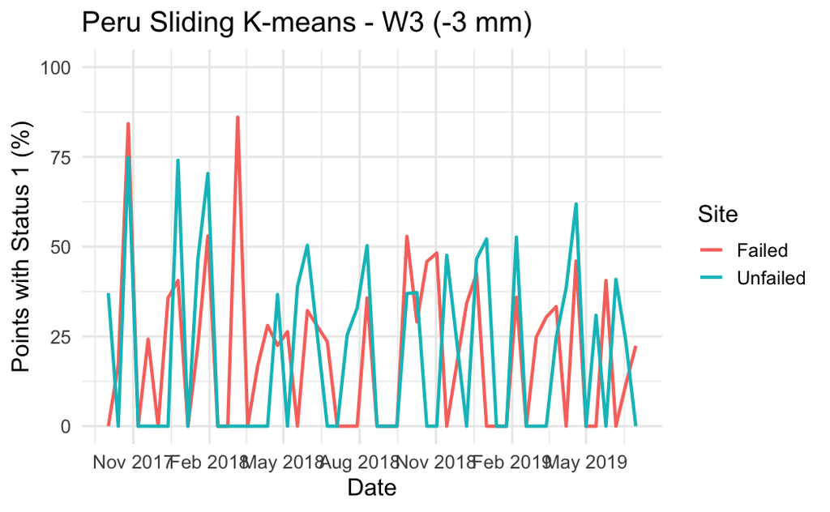

```r
# Peru W3 displacement (-3 mm)
p_peru_w3 <- plot_status_comparison(
  peru_F_w3,
  peru_U_w3,
  peru_F_w3_status,
  peru_U_w3_status,
  "Peru Sliding K-means - W3 (-3 mm)"
)

# Peru W5 displacement (-4 mm)
p_peru_w5 <- plot_status_comparison(
  peru_F_w5,
  peru_U_w5,
  peru_F_w5_status,
  peru_U_w5_status,
  "Peru Sliding K-means - W5 (-4 mm)"
)

# Peru W10 displacement (-5 mm)
p_peru_w10 <- plot_status_comparison(
  peru_F_w10,
  peru_U_w10,
  peru_F_w10_status,
  peru_U_w10_status,
  "Peru Sliding K-means - W10 (-5 mm)"
)

p_peru_w3
```

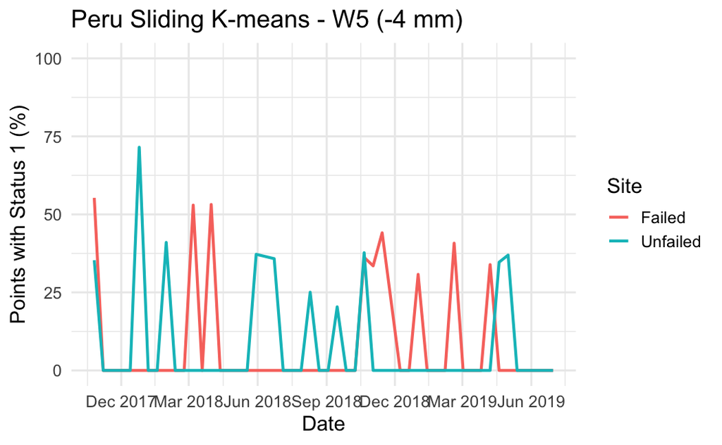

```r
p_peru_w5
```

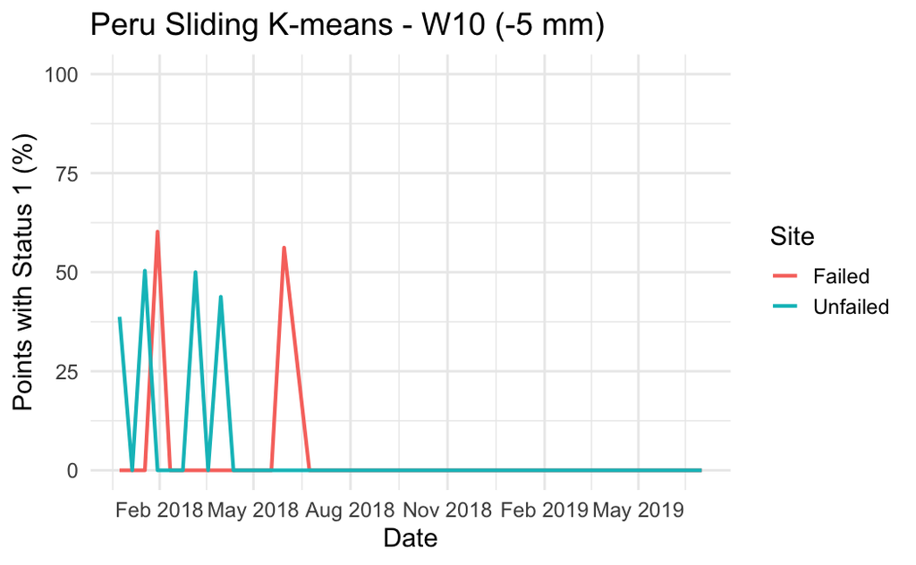

```r
p_peru_w10
```

```r
ggsave(
  "../outputs/peru_sliding_w3_displacement.png",
  plot = p_peru_w3,
  width = 10,
  height = 7,
  dpi = 300
)

ggsave(
  "../outputs/peru_sliding_w5_displacement.png",
  plot = p_peru_w5,
  width = 10,
  height = 7,
  dpi = 300
)

ggsave(
  "../outputs/peru_sliding_w10_displacement.png",
  plot = p_peru_w10,
  width = 10,
  height = 7,
  dpi = 300
)
```

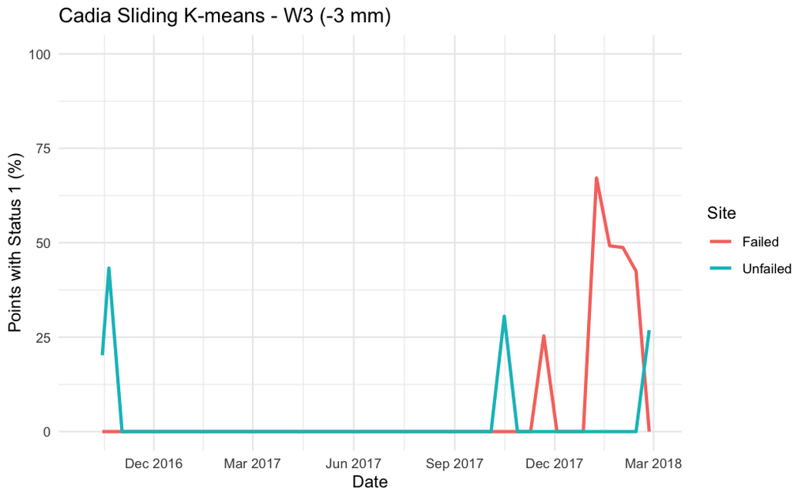

```r
# editing axes and re-exporting

# Consistent Cadia x-axis
cadia_axis <- scale_x_date(
  limits = as.Date(c("2016-10-01", "2018-03-01")),
  date_breaks = "3 months",
  date_labels = "%b %Y"
)

p_cadia_w3 <- p_cadia_w3 + cadia_axis
p_cadia_w5 <- p_cadia_w5 + cadia_axis
p_cadia_w10 <- p_cadia_w10 + cadia_axis


# Consistent Peru x-axis
peru_axis <- scale_x_date(
  limits = as.Date(c("2017-10-01", "2019-07-01")),
  date_breaks = "3 months",
  date_labels = "%b %Y"
)

p_peru_w3 <- p_peru_w3 + peru_axis
p_peru_w5 <- p_peru_w5 + peru_axis
p_peru_w10 <- p_peru_w10 + peru_axis


# Display updated plots
p_cadia_w3
```

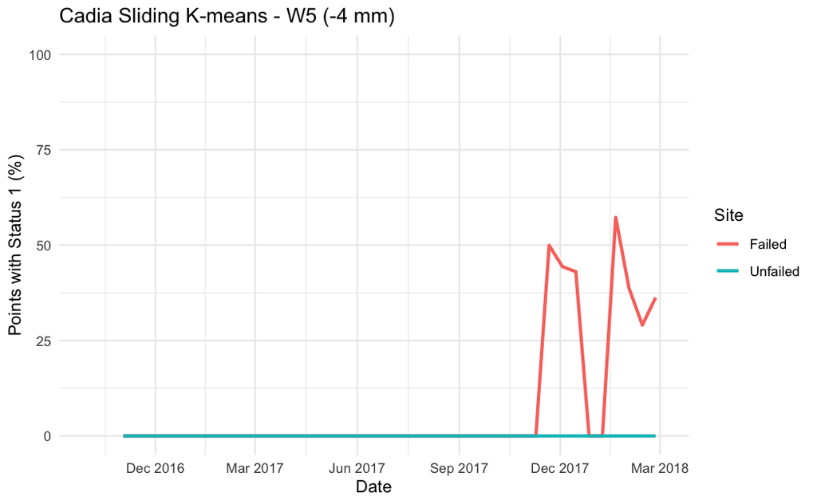

```r
p_cadia_w5
```

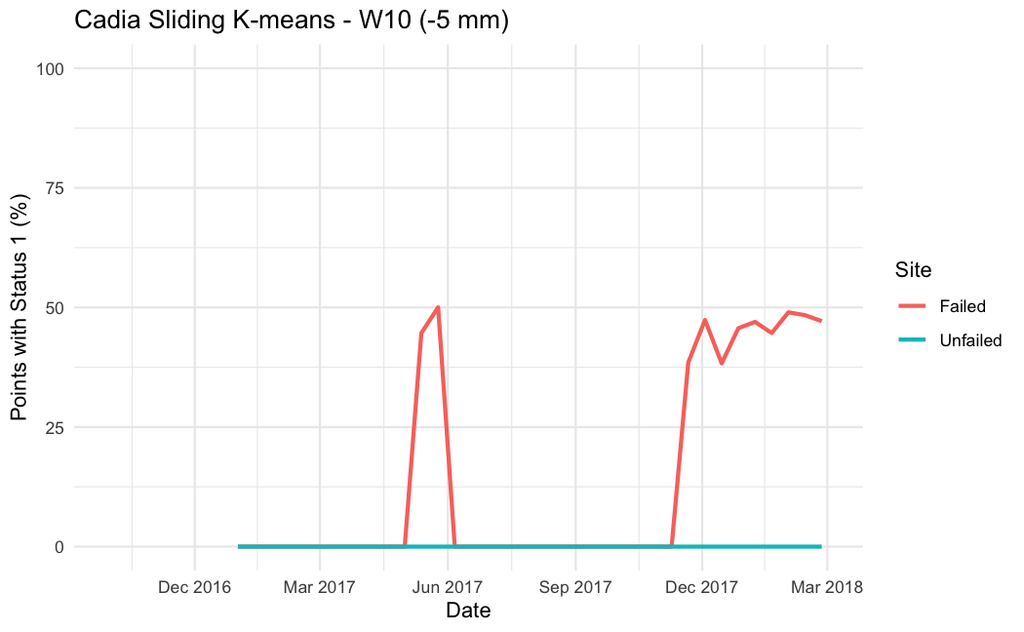

```r
p_cadia_w10
```

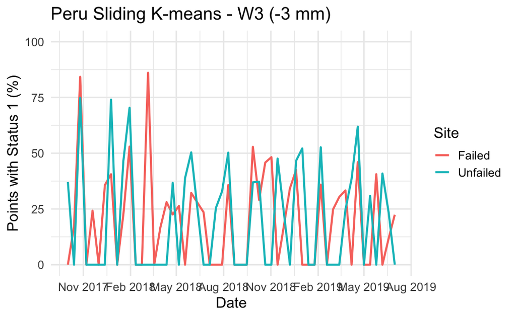

```r
p_peru_w3
```

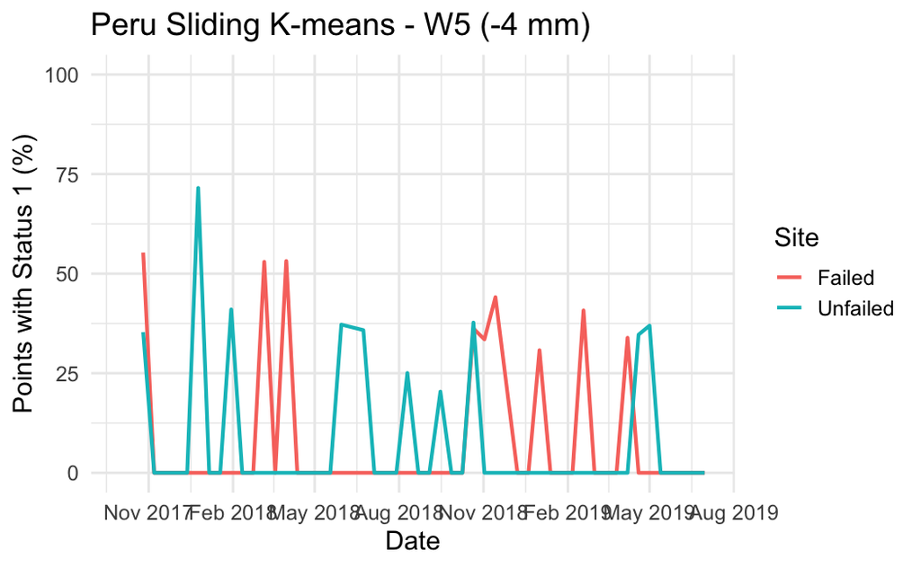

```r
p_peru_w5
```

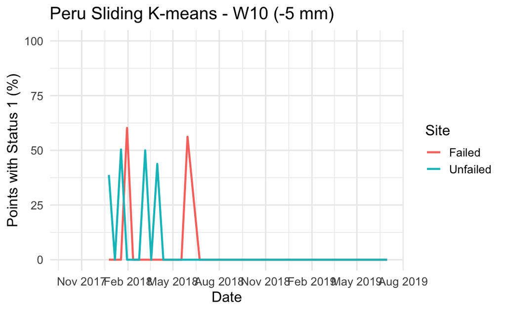

```r
p_peru_w10
```

```r
# CADIA

ggsave(
  "../outputs/cadia_displacement_status_w3.png",
  plot = p_cadia_w3,
  width = 10, height = 7, dpi = 300
)

ggsave(
  "../outputs/cadia_sliding_w5_displacement.png",
  plot = p_cadia_w5,
  width = 10, height = 7, dpi = 300
)

ggsave(
  "../outputs/cadia_sliding_w10_displacement.png",
  plot = p_cadia_w10,
  width = 10, height = 7, dpi = 300
)


# PERU

ggsave(
  "../outputs/peru_sliding_w3_displacement.png",
  plot = p_peru_w3,
  width = 10, height = 7, dpi = 300
)

ggsave(
  "../outputs/peru_sliding_w5_displacement.png",
  plot = p_peru_w5,
  width = 10, height = 7, dpi = 300
)

ggsave(
  "../outputs/peru_sliding_w10_displacement.png",
  plot = p_peru_w10,
  width = 10, height = 7, dpi = 300
)
```

#### 4.5.5 Exporting

```r
# Exporting sw function

make_sliding_export <- function(
  result,
  status,
  point_info
) {

  n_iters <- ncol(result$membership)

  export_df <- do.call(
    rbind,
    lapply(1:n_iters, function(iter) {

      data.frame(
        PointID = point_info$PointID,
        lon = point_info$lon,
        lat = point_info$lat,

        Date = as.Date(
          sub(
            "^D_",
            "",
            result$iter_dates[iter]
          ),
          format = "%Y%m%d"
        ),

        Cluster = result$membership[, iter],
        Status = status[, iter]
      )
    })
  )

  return(export_df)
}
```

```r
# original info

# Cadia failed metadata
cadia_info <- cadia_co_filtered %>%
  mutate(PointID = row_number()) %>%
  select(PointID, lon, lat)

# Cadia South metadata
cadia_south_info <- cadia_south_nonfailure_co_filtered %>%
  mutate(PointID = row_number()) %>%
  select(PointID, lon, lat)
```

```r
peru_F_export_info <- peru_F_info %>%
  transmute(
    PointID = FID,
    lon = lon,
    lat = lat
  )

peru_U_export_info <- peru_U_info %>%
  transmute(
    PointID = FID,
    lon = lon,
    lat = lat
  )
```

```r
# converting w/ function

# Cadia (F)

cadia_F_w3_export <- make_sliding_export(
  cadia_F_w3,
  cadia_F_w3_status,
  cadia_info
)

cadia_F_w5_export <- make_sliding_export(
  cadia_F_w5,
  cadia_F_w5_status,
  cadia_info
)

cadia_F_w10_export <- make_sliding_export(
  cadia_F_w10,
  cadia_F_w10_status,
  cadia_info
)


# Cadia (U)

cadia_S_w3_export <- make_sliding_export(
  cadia_S_w3,
  cadia_S_w3_status,
  cadia_south_info
)

cadia_S_w5_export <- make_sliding_export(
  cadia_S_w5,
  cadia_S_w5_status,
  cadia_south_info
)

cadia_S_w10_export <- make_sliding_export(
  cadia_S_w10,
  cadia_S_w10_status,
  cadia_south_info
)


# Peru (F)

peru_F_w3_export <- make_sliding_export(
  peru_F_w3,
  peru_F_w3_status,
  peru_F_export_info
)

peru_F_w5_export <- make_sliding_export(
  peru_F_w5,
  peru_F_w5_status,
  peru_F_export_info
)

peru_F_w10_export <- make_sliding_export(
  peru_F_w10,
  peru_F_w10_status,
  peru_F_export_info
)


# Peru (U)

peru_U_w3_export <- make_sliding_export(
  peru_U_w3,
  peru_U_w3_status,
  peru_U_export_info
)

peru_U_w5_export <- make_sliding_export(
  peru_U_w5,
  peru_U_w5_status,
  peru_U_export_info
)

peru_U_w10_export <- make_sliding_export(
  peru_U_w10,
  peru_U_w10_status,
  peru_U_export_info
)
```

```r
# Check
head(cadia_F_w5_export)
head(peru_F_w5_export)

dim(cadia_F_w5_export)
dim(peru_F_w5_export)

table(cadia_F_w5_export$Status)
table(peru_F_w5_export$Status)
```

```r
# Exporting

# Cadia failed
write.csv(
  cadia_F_w3_export,
  "../outputs/cadia_failed_sw_w3_km2_thresh3.csv",
  row.names = FALSE
)

write.csv(
  cadia_F_w5_export,
  "../outputs/cadia_failed_sw_w5_km2_thresh4.csv",
  row.names = FALSE
)

write.csv(
  cadia_F_w10_export,
  "../outputs/cadia_failed_sw_w10_km2_thresh5.csv",
  row.names = FALSE
)


# Cadia unfailed
write.csv(
  cadia_S_w3_export,
  "../outputs/cadia_unfailed_sw_w3_km2_thresh3.csv",
  row.names = FALSE
)

write.csv(
  cadia_S_w5_export,
  "../outputs/cadia_unfailed_sw_w5_km2_thresh4.csv",
  row.names = FALSE
)

write.csv(
  cadia_S_w10_export,
  "../outputs/cadia_unfailed_sw_w10_km2_thresh5.csv",
  row.names = FALSE
)


# Peru failed
write.csv(
  peru_F_w3_export,
  "../outputs/peru_failed_sw_w3_km2_thresh3.csv",
  row.names = FALSE
)

write.csv(
  peru_F_w5_export,
  "../outputs/peru_failed_sw_w5_km2_thresh4.csv",
  row.names = FALSE
)

write.csv(
  peru_F_w10_export,
  "../outputs/peru_failed_sw_w10_km2_thresh5.csv",
  row.names = FALSE
)


# Peru unfailed
write.csv(
  peru_U_w3_export,
  "../outputs/peru_unfailed_sw_w3_km2_thresh3.csv",
  row.names = FALSE
)

write.csv(
  peru_U_w5_export,
  "../outputs/peru_unfailed_sw_w5_km2_thresh4.csv",
  row.names = FALSE
)

write.csv(
  peru_U_w10_export,
  "../outputs/peru_unfailed_sw_w10_km2_thresh5.csv",
  row.names = FALSE
)
```

```r
write.csv(
  peru_U_w10_export,
  "../outputs/peru_unfailed_sw_w10_km2_thresh5.csv",
  row.names = FALSE
)
```